# How long do people stay in forest?

Kang

## Introduction

I am trying to make a new analysis based on Amami Agoop data. It is a human mobility science and ecosystem service research, trying to answer the following questions. How long do people stay in the areas of interest, for example, inside national park, conservation area, forest? How many people go to those areas, and how does it vary by season? What factors drive the stay time and visitor number pattern? And maybe we can get answer for some questions in the real world by answering the above questions like: why do people go to Amami? Do they just want to go to beaches and cities, or they visit it because of the high biodiversity? If most visitor go there for sun and beaches, and exotic feeling, then there is a potential of making use of the high biodiversity in tourism. Besides, how many people and how long do people stay in conservation areas? If people disturb conservation areas frequently during breeding season, the risk should be addressed.

Other than scientific and conservation reasons, the other motivations are as follows.  
- Make use of the advantages of the Agoop data.  
- The code might be helpful to Jiajia and other members who are interested in stay time analysis.  
- Now that we have the data, we don’t want to waste it.

## Method and Results

Similar to the Sapporo study, we need to identify the areas of interest first. The areas of interest in Sapporo study is the parks, while those of this study should be conservation areas. I take Kinsakubaru (金作原) as an example here. Kinsakubaru is roughly defined as a buffer circle here.

```r
mapview(kinsakubaru)
```

[interactive chart not shown]

Then we need to do analysis to the visitors who has visited and stayed in this area for at least 15 minutes (less than 15 minutes is regarded as passing the area). So, among the 80,000 visitors in 2018, about 100 visitors has visited the area. It is not a small proportion if we exclude the local residents, and we will have more visitor of interest after we define more areas of interest.

Most visitors stayed in the area less than 150 minutes. There are two peaks of the stay time.

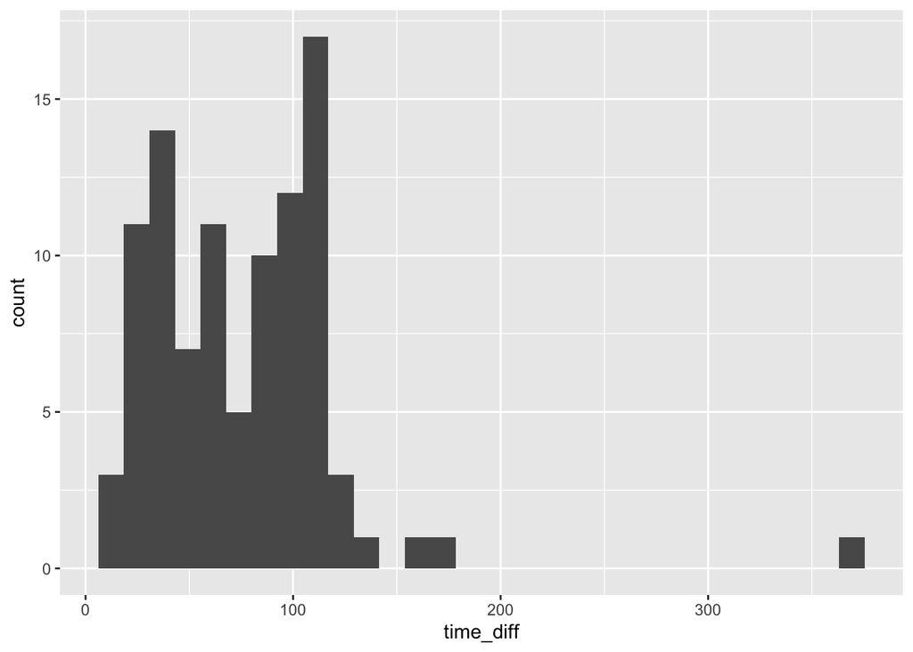

```r
ggplot(gis_agoop_kinsakubaru_time) +
  geom_histogram(aes(time_diff))
```

Regarding the seasonal variety, though the total visitors of the island do not have a obvious seasonal pattern:

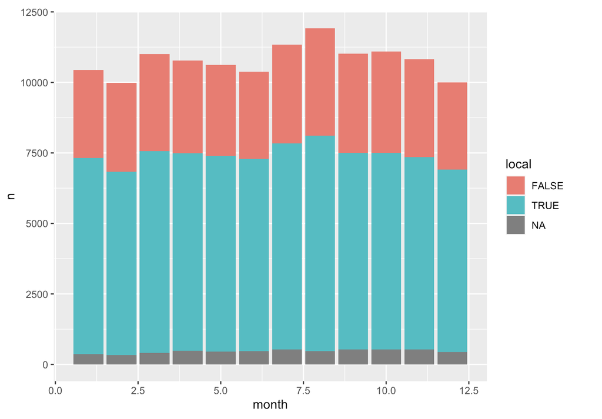

But the visitor of Kinsakubaru area has a seasonal pattern:

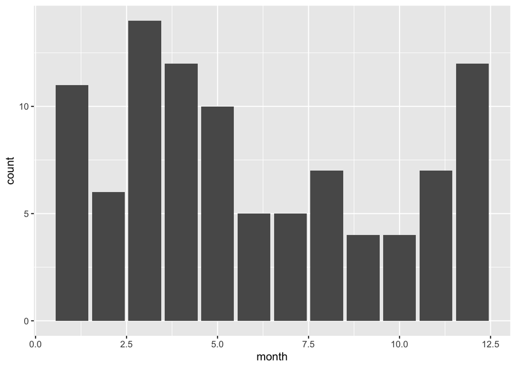

```r
# Monthly change of visitor number.
plt_mth_num
```

There stay time also has a seasonal pattern:

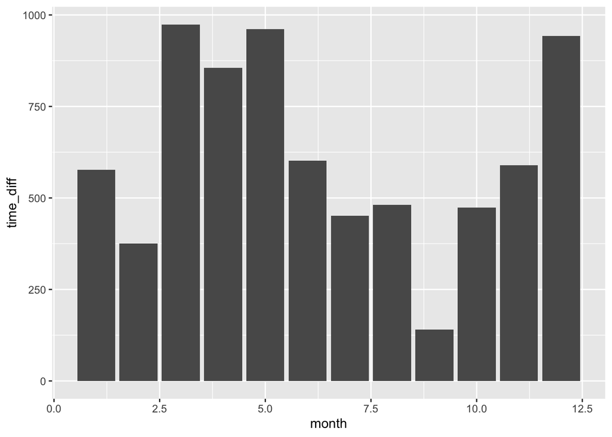

```r
# Monthly change of stay time.
plt_mth_time
```

The weather and holiday might have impacts on both visitor number and stay time to the Kinsakubaru area. Firstly, 2 examples of the impacts on visitor number:

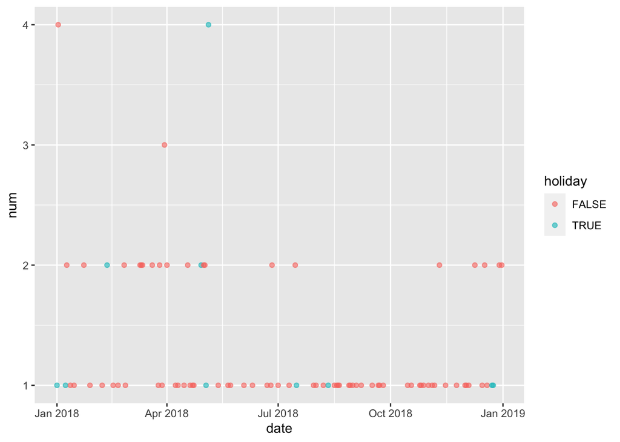

```r
plt_holiday_num
```

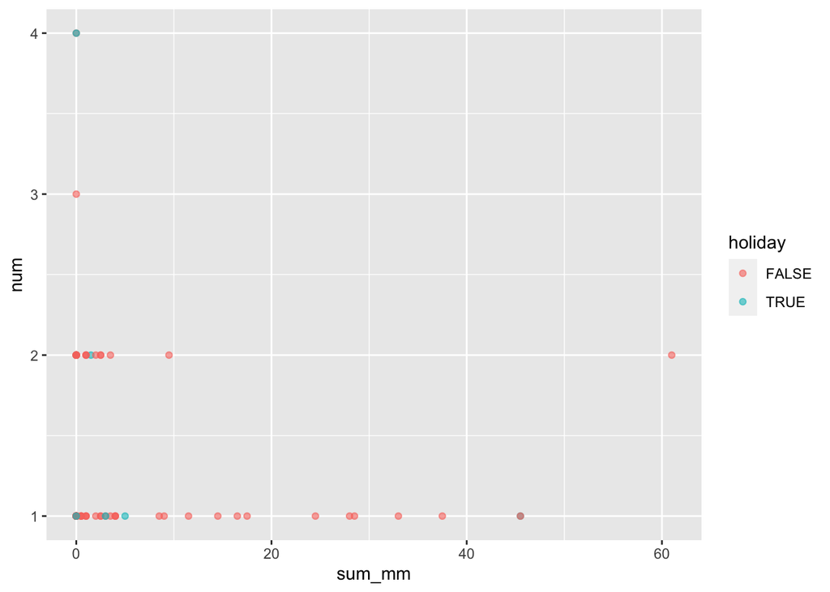

```r
plt_weather_num
```

Then impacts on stay time:

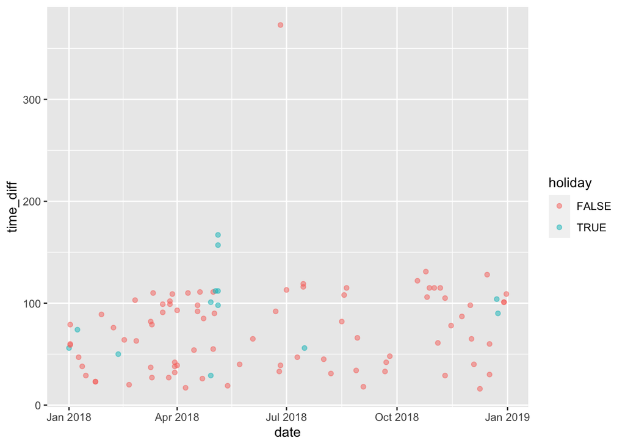

```r
# Holiday ~ stay time.
plt_holiday_time
```

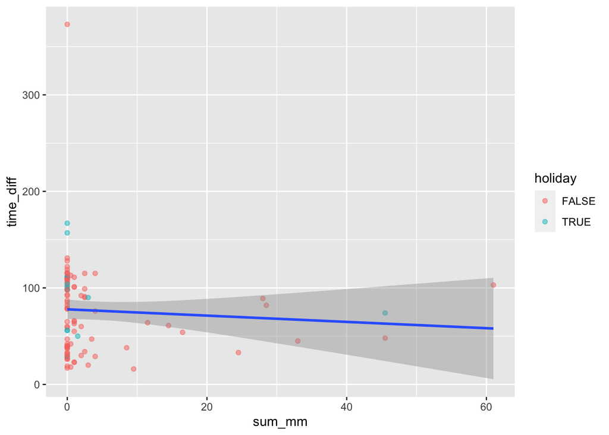

```r
# Weather (precipitation) ~ stay time.
plt_weather_time
```

Will use models like GLM to quantify the impacts of holiday and weather.

## Challenges

$1$ How to identify the target areas? The best should be to identify the areas where visitors go for biodiversity tour, for example, Santaro area and Kinsakubaru area. But it is difficult to find that areas - if we can collect that from tour guides on the island, that would be great though. Another problem is that the areas do not have a clear boundary. So instead, I may use some land use map of the national park to identify the areas of interest. For example, there is a [map](https://www.rinya.maff.go.jp/kyusyu/keikaku/hogorin/shinrin_seitaikei/amamigunntou.html) showing the conservation areas on the island. However, it has some problems as well. For exmaple, we don’t know if the conservation areas are accessible for visitors, we should exclude the areas where people can’t access.

$2$ Even if we identify the areas of interest, we should consider more about the comparison of stay time and visitors. For example, if an area of interest is larger, then it is more possible that a visitor will stay longer there.

### Key References

$$1$$
Jaung, W., Carrasco, L.R., 2021. Using mobile phone data to examine weather impacts on recreational ecosystem services in an urban protected area. Scientific Reports 11, 1–11.
$$2$$
Montaño, J., Rossello, J., Sanso, A., 2019. A new method for estimating tourists' length of stay. Tourism Management 75, 112–120.